# Simulation_hw1

Will Burton

November 12, 2016

# Simulation Homework 1

Simulate possible future values of 2017 drilling costs.  
* Currently, only previous information is available for 1960 - 2007. * Since the industry has changed tremendously over those decades, only the information from 1990 - 2006 will be useful for this analysis. 2007 was an outlier and should be ignored. *Instead of looking at the distribution of actual costs, the Company’s analysts recommend simulating possible annual changes in costs to get to 2017.

They have calculated geometric changes in the data set already, but they are open to other options if you explain why you chose them. * Instead of focusing on costs for oil, gas, and dry wells individually, the Company’s analysts recommend to treat them all equally and assume an average cost applies to them all. (HINT: You should have 48 observations. Geometric changes from 1991 - 2006.)  
Previously the Price Analysis group has worked under the assumption that these geometric changes from one year to the next follow a Normal distribution. Use QQ-plots or formal tests to see if you agree.

Build a kernel density estimate of the distribution of geometric changes, using the 48 observations described above.  
Simulate possible future values of 2017 drilling costs under both the assumption of Normality as well as under the kernel density estimate you created (HINT: Run two simulations). Make a recommendation for which one you feel the company should use.

Start off loading the R packages and the data

```r
library(tidyr)
library(dplyr)
library(ggplot2)
library(ks)
setwd('C:/Users/Will/Documents/MSA/fall3/simulation/data')
cost <- read.csv('cost.csv')
```

Before we combine the costs into one column, lets explore the data and determine if we really can combine them into one distribution

```r
#####################################################
################ Exploration ########################
#####################################################

#2007 is an outlier and should be ignored
cost <- cost[cost$Date >=1991 & cost$Date < 2007,]
cost$oil_return <- as.numeric(as.character(cost$oil_return))
cost$gas_return <- as.numeric(as.character(cost$gas_return))
cost$dry_return <- as.numeric(as.character(cost$dry_return))

#look at different costs
cost %>%
  select(Date, oil_well_cost, gas_well_cost, dry_well_cost) %>%
  gather(key = 'type', value = 'cost', oil_well_cost,
         gas_well_cost, dry_well_cost)-> drill_types_cost
```

Examine drilling costs over time

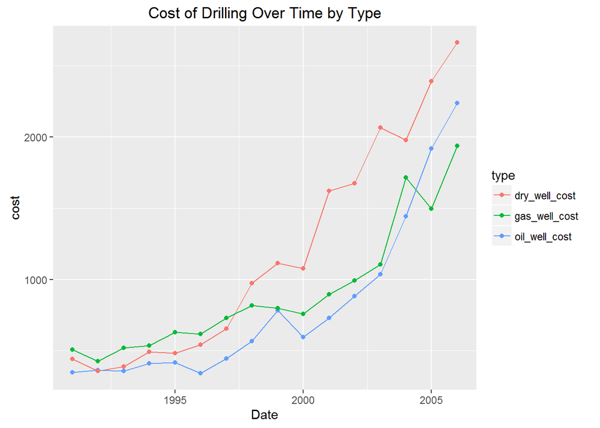

```r
ggplot(drill_types_cost, aes(x = Date, y = cost, color = type)) + geom_line() +
  geom_point() + ggtitle('Cost of Drilling Over Time by Type')
```

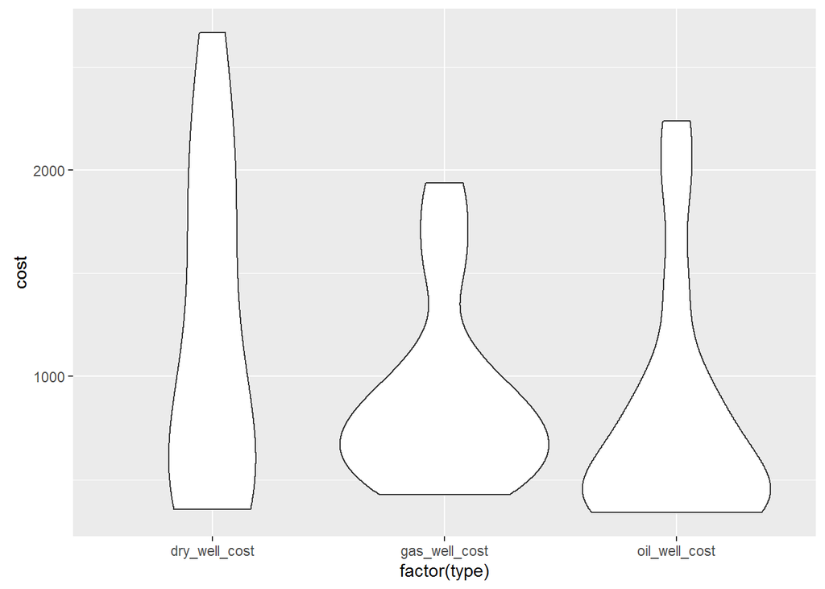

```r
ggplot(drill_types_cost, aes(factor(type), cost)) + geom_violin()
```

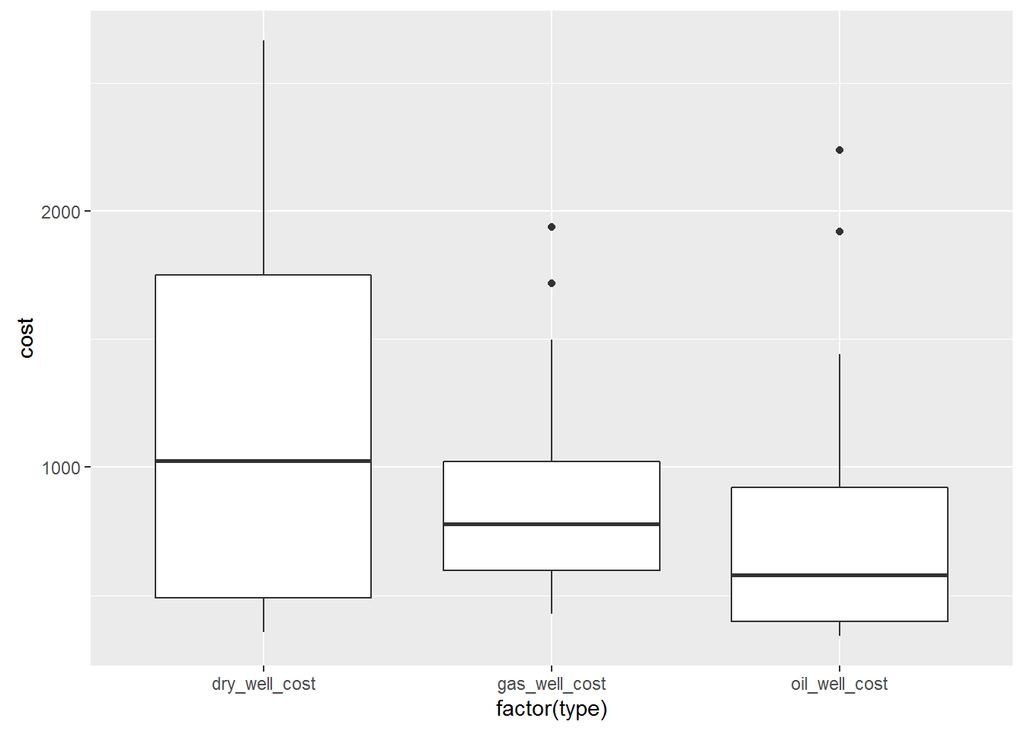

```r
ggplot(drill_types_cost, aes(factor(type), cost)) + geom_boxplot()
```

Now lets look at the geometric changes over time

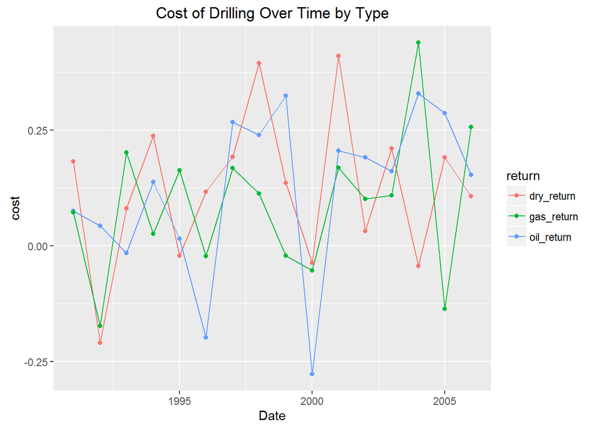

```r
#performing an anova on the costs across the different types,
# there is no difference among groups and the associated cost

#look at geometric changes in cost over time
cost %>%
  select(Date, oil_return, gas_return, dry_return) %>%
  gather(key = 'return', value = 'cost', oil_return,
         gas_return, dry_return) %>%
  mutate(cost = as.numeric(cost))-> drill_types_pct
ggplot(drill_types_pct, aes(x = Date, y = cost, color = return)) + geom_line() +
  geom_point() + ggtitle('Cost of Drilling Over Time by Type')
```

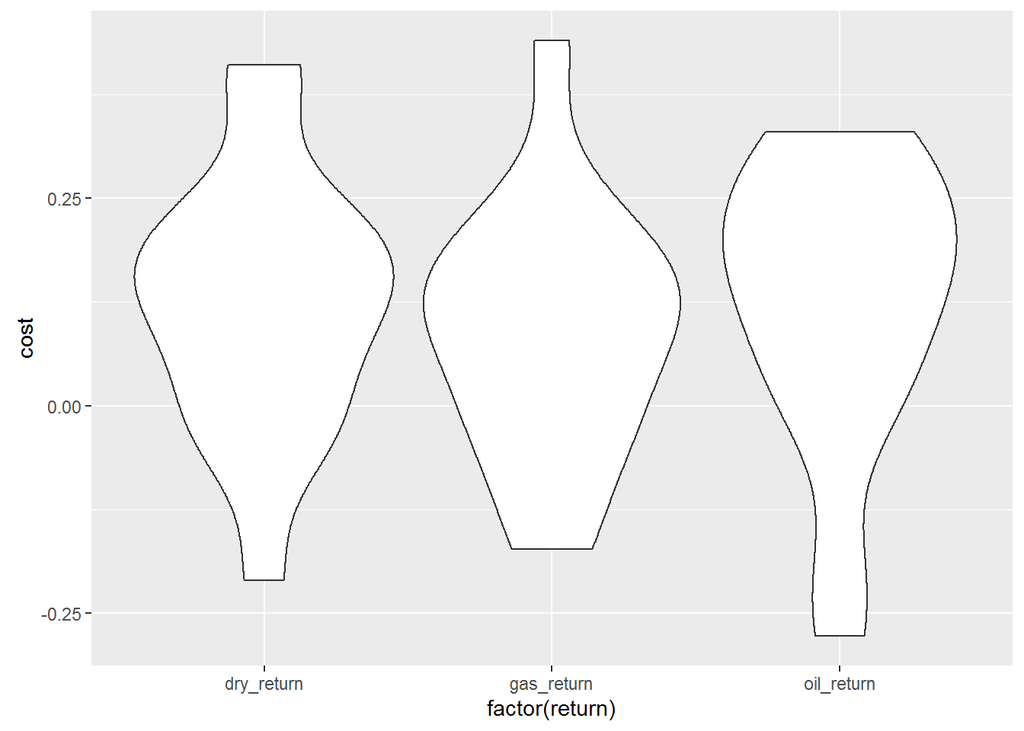

```r
ggplot(drill_types_pct, aes(factor(return), cost)) + geom_violin()
```

Now we perform an ANOVA to see if there are any differences between the different types of drilling: If there are differences then we should not combine them into the same group

```r
fit <- aov(cost ~ type, data = drill_types_cost)
summary(fit)
```

```
##             Df   Sum Sq Mean Sq F value Pr(>F)
## type         2  1224568  612284   1.598  0.214
## Residuals   45 17242132  383158
```

```r
#anova assumptions:
#1. equal variance across groups
#2. errors are normally distributed
#3. observations are independent

#1.
#check for equal variance
bartlett.test(drill_types_pct$cost, factor(drill_types_pct$return))
```

```
##
##  Bartlett test of homogeneity of variances
##
## data:  drill_types_pct$cost and factor(drill_types_pct$return)
## Bartlett's K-squared = 0.28329, df = 2, p-value = 0.8679
```

```r
car::leveneTest(drill_types_pct$cost, factor(drill_types_pct$return))
```

```
## Levene's Test for Homogeneity of Variance (center = median)
##       Df F value Pr(>F)
## group  2  0.0832 0.9203
##       45
```

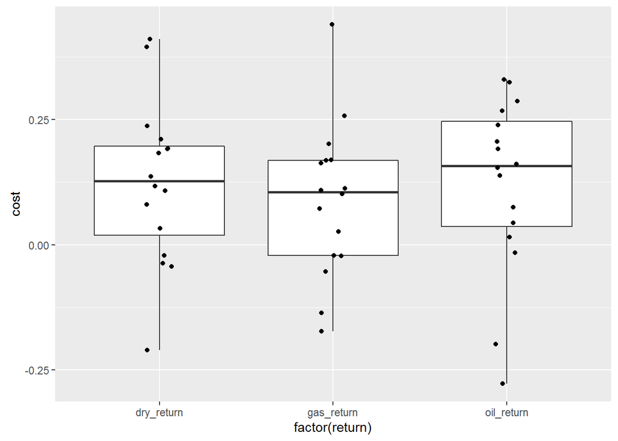

```r
ggplot(drill_types_pct, aes(factor(return), cost)) + geom_boxplot() +
  geom_point(position = position_jitter(width = 0.2))
```

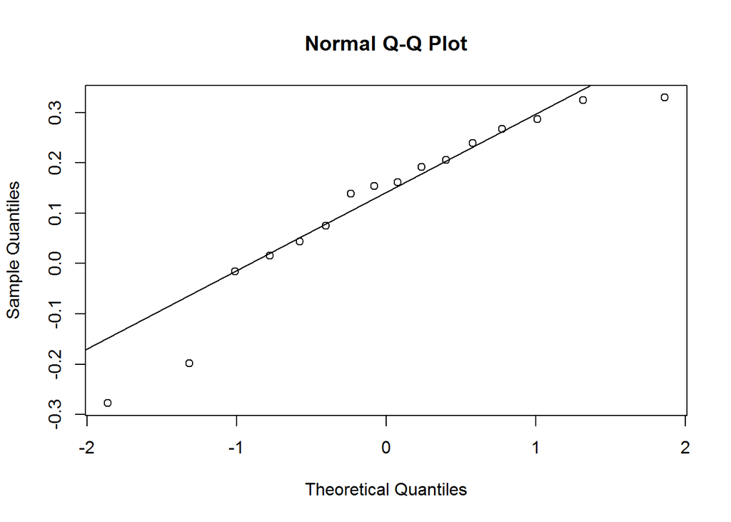

```r
#Both the levene's test and bartletts test failed to reject the null

#2.
# Check for normality
qqnorm(drill_types_pct$cost[drill_types_pct$return == 'oil_return'])
qqline(drill_types_pct$cost[drill_types_pct$return == 'oil_return'])
```

```r
nortest::ad.test(drill_types_pct$cost[drill_types_pct$return == 'oil_return'])
```

```
##
##  Anderson-Darling normality test
##
## data:  drill_types_pct$cost[drill_types_pct$return == "oil_return"]
## A = 0.47486, p-value = 0.2072
```

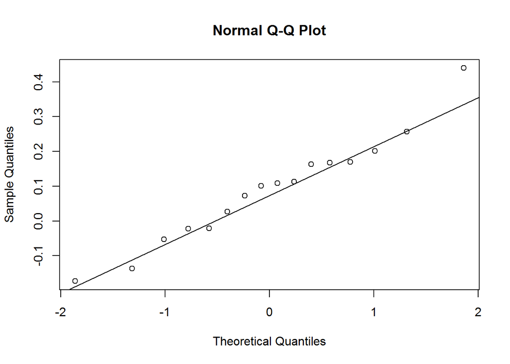

```r
qqnorm(drill_types_pct$cost[drill_types_pct$return == 'gas_return'])
qqline(drill_types_pct$cost[drill_types_pct$return == 'gas_return'])
```